# ggplot - last notes

## 1.10 legend

for legends to be merged, they must have the same name. So if you change the name of one of the scales, you’ll need to change it for all of them. One way to do this is by using `labs()` helper function:

```r
toy <- data.frame(
  const = 1,
  up = 1:4,
  txt = letters[1:4],
  big = (1:4)*1000,
  log = c(2, 5, 10, 2000)
)
toy
```

```
##   const up txt  big  log
## 1     1  1   a 1000    2
## 2     1  2   b 2000    5
## 3     1  3   c 3000   10
## 4     1  4   d 4000 2000
```

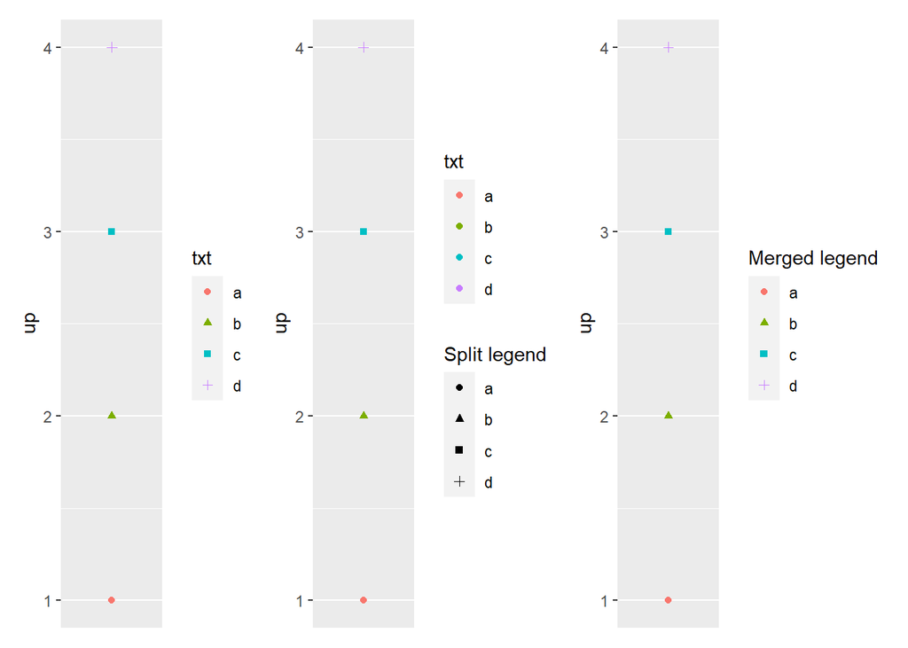

```r
base <- ggplot(toy, aes(const, up)) +
  geom_point(aes(shape = txt, colour = txt)) +
  scale_x_continuous(NULL, breaks = NULL)

p1 <- base
p2 <- base + labs(shape = "Split legend")
p3 <- base + labs(shape = "Merged legend", colour = "Merged legend")

p1 + p2 + p3
```

# 2 colors

In R, colors can be specified either by name (e.g `col = “red”`) or as a hexadecimal RGB triplet (such as `col = “#FFCC00”`) You can also use other color systems R knows 657 colors by name here are the first 60

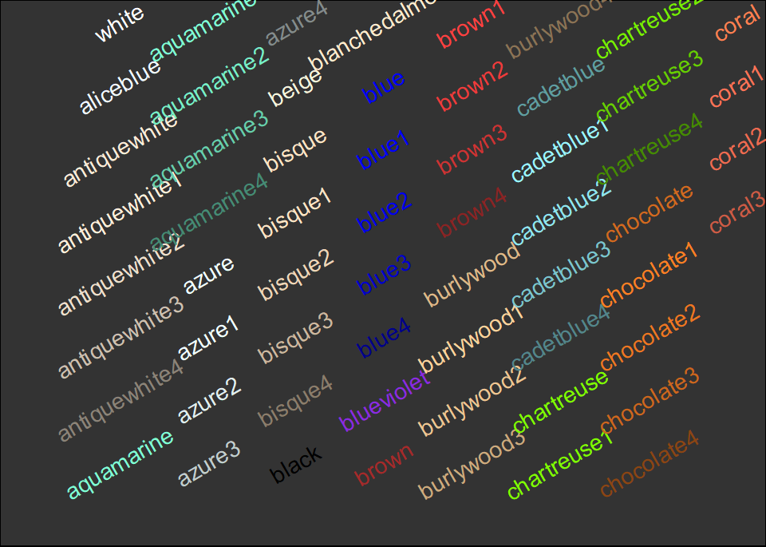

```r
showCols <- function(cl=colors(), bg = "grey",
                     cex = 0.75, rot = 30) {
    m <- ceiling(sqrt(n <-length(cl)))
    length(cl) <- m*m; cm <- matrix(cl, m)
    require("grid")
    grid.newpage(); vp <- viewport(w = .92, h = .92)
    grid.rect(gp=gpar(fill=bg))
    grid.text(cm, x = col(cm)/m, y = rev(row(cm))/m, rot = rot,
              vp=vp, gp=gpar(cex = cex, col = cm))
  }

showCols(bg="gray20",cl=colors()[1:60], rot=30, cex=0.9)
```

Colors can be specified using hexadecimal color code, such as `“#FFC00”` and there are ready made color palettes:

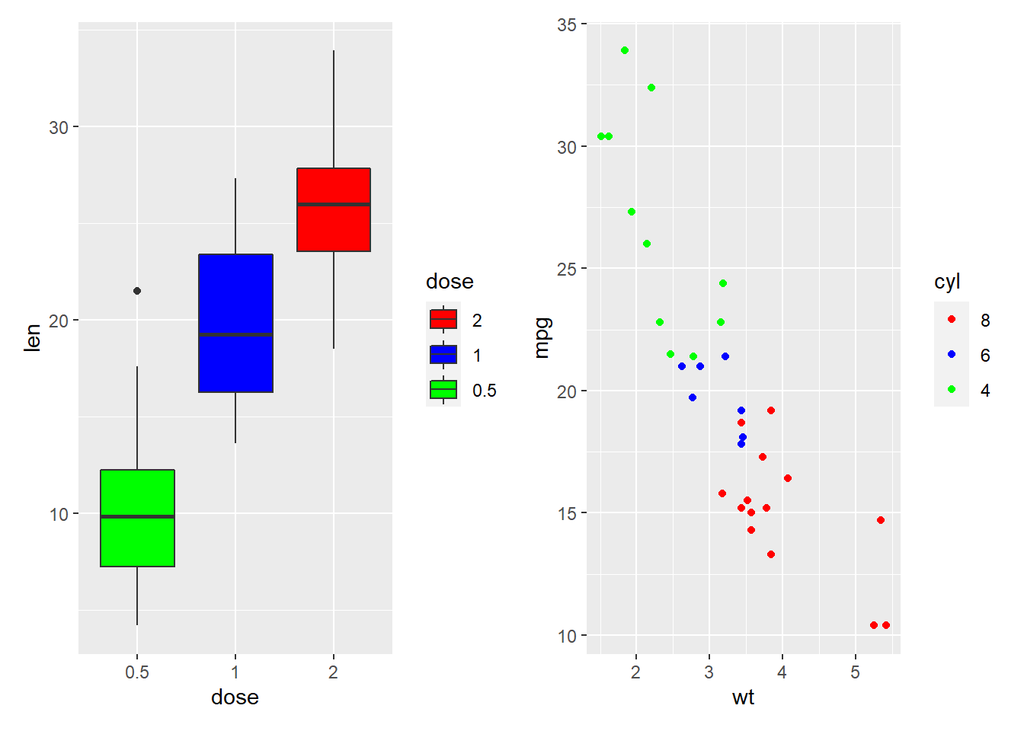

```r
ToothGrowth$dose <- as.factor(ToothGrowth$dose)
mtcars$cyl <- as.factor(mtcars$cyl)

bp <- ggplot(ToothGrowth, aes(x=dose, y=len, fill=dose)) +
  geom_boxplot()

sp <- ggplot(mtcars, aes(x=wt, y=mpg, color=cyl)) + geom_point()
# Box plot

p1 <- bp + scale_fill_manual(breaks = c("2", "1", "0.5"),
                       values=c("red", "blue", "green"))
# Scatter plot
p2 <- sp + scale_color_manual(breaks = c("8", "6", "4"),
                        values=c("red", "blue", "green"))
p1 + p2
```

change manually discrete:  
`scale_fill_manual()` for box plot, bar plot, violin plot, etc  
`scale_color_manual()` for lines and points

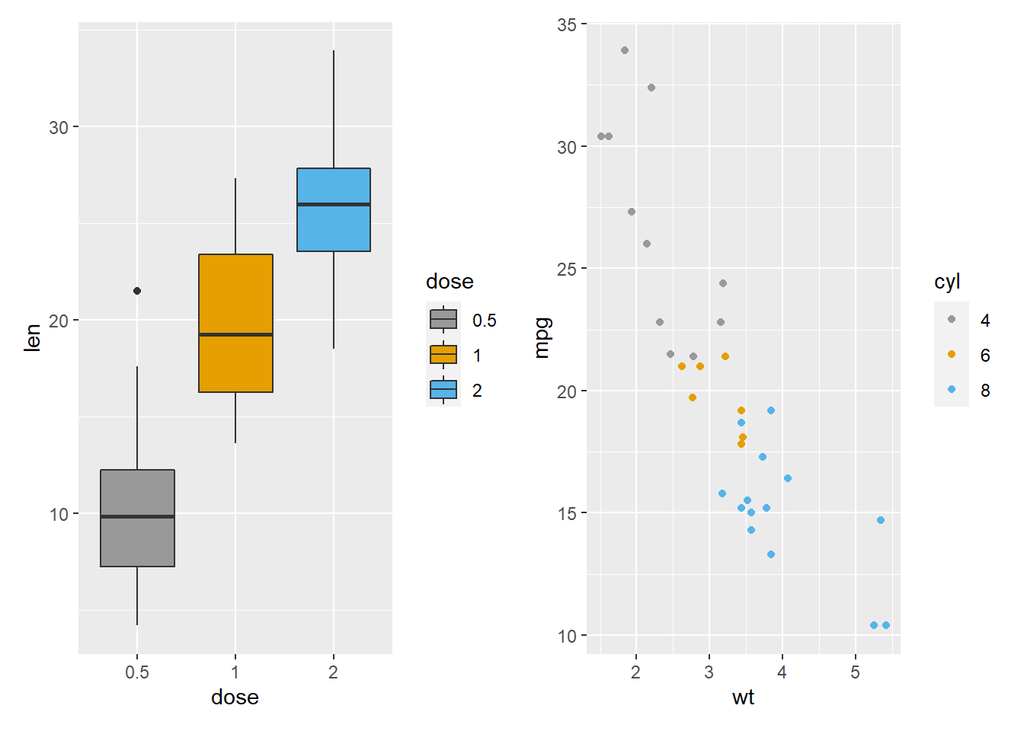

```r
# Box plot
p1 <- bp + scale_fill_manual(values=c("#999999", "#E69F00", "#56B4E9"))
# Scatter plot
p2 <- sp + scale_color_manual(values=c("#999999", "#E69F00", "#56B4E9"))

p1 + p2
```

better work with naming the values:

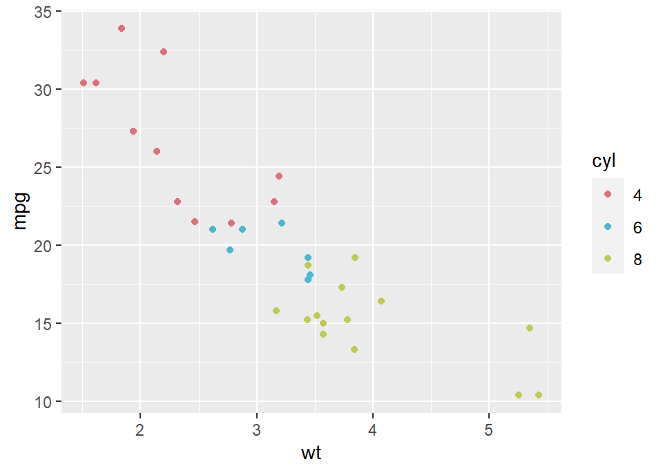

```r
colors <- c("4" = "#D9717D", "6" = "#4DB6D0", "8" = "#BECA55")

sp +  scale_color_manual(values = colors)
```

the argument breaks can be used to control the appearance of the legend. This holds true also for the other `scale_xx()` functions.

## 2.1 color pallets

```r
library("RColorBrewer")
# display.brewer.all()
```

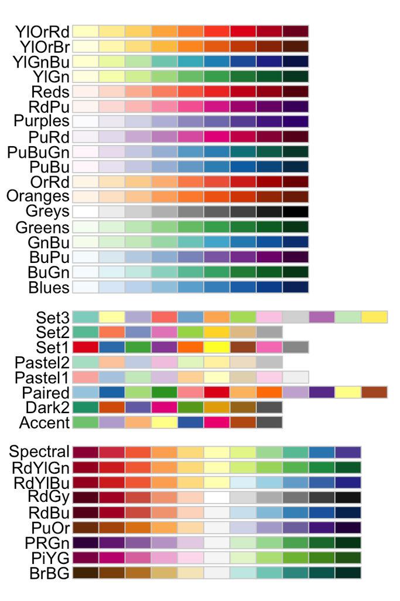

There are 3 types of palettes : sequential, diverging, and qualitative.

**Sequential** palettes are suited to ordered data that progress from low to high (gradient). The palettes names are : Blues, BuGn, BuPu, GnBu, Greens, Greys, Oranges, OrRd, PuBu, PuBuGn, PuRd, Purples, RdPu, Reds, YlGn, YlGnBu YlOrBr, YlOrRd.

**Diverging** palettes put equal emphasis on mid-range critical values and extremes at both ends of the data range. The diverging palettes are : BrBG, PiYG, PRGn, PuOr, RdBu, RdGy, RdYlBu, RdYlGn, Spectral

**Qualitative** palettes are best suited to representing nominal or categorical data. They not imply magnitude differences between groups. The palettes names are : Accent, Dark2, Paired, Pastel1, Pastel2, Set1, Set2, Set3

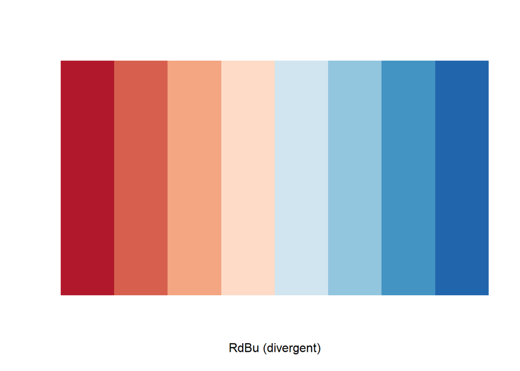

```r
display.brewer.pal(n = 8, name = 'RdBu')
```

```r
# Hexadecimal color specification
brewer.pal(n = 8, name = "RdBu")
```

```
## [1] "#B2182B" "#D6604D" "#F4A582" "#FDDBC7" "#D1E5F0" "#92C5DE" "#4393C3"
## [8] "#2166AC"
```

use color palettes

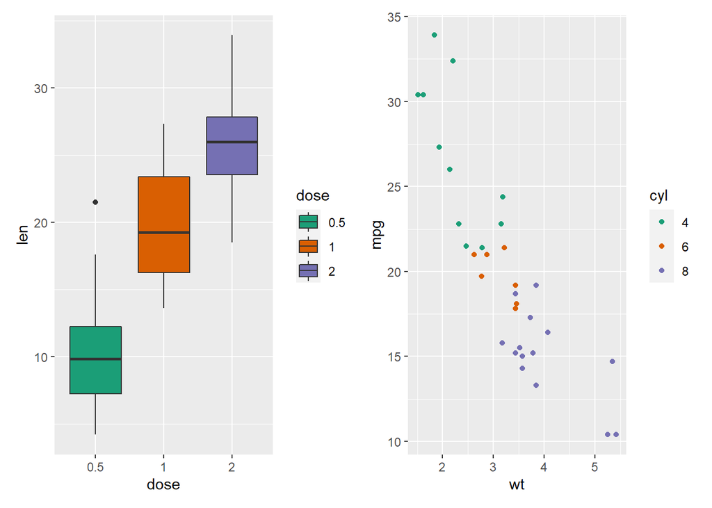

```r
# Box plot
p1 <- bp + scale_fill_brewer(palette="Dark2")
# Scatter plot
p2 <- sp + scale_color_brewer(palette="Dark2")

p1 + p2
```

The graph can be colored according to the values of a continuous variable using the functions :

`scale_color_gradient()`, `scale_fill_gradient()` for sequential gradients between two colors.  
`scale_color_gradient2()`, `scale_fill_gradient2()` for diverging gradients.  
`scale_color_gradientn()`, `scale_fill_gradientn()` for gradient between n colors Gradient colors for scatter plots.

The graphs are colored using the qsec continuous variable :

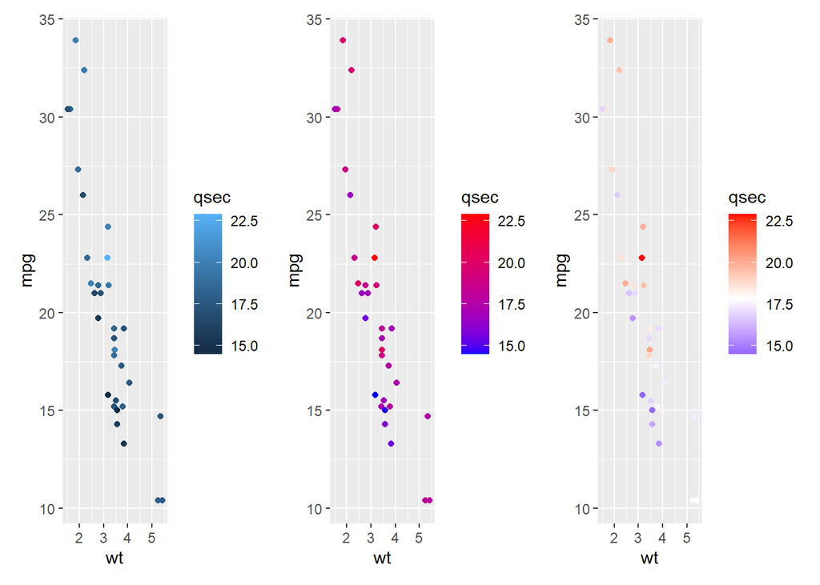

```r
# Color by qsec values
p1 <- ggplot(mtcars, aes(x=wt, y=mpg, color=qsec)) + geom_point()


# Change the low and high colors
# Sequential color scheme
p2 <- p1 + scale_color_gradient(low="blue", high="red")

# Diverging color scheme
mid <- mean(mtcars$qsec)

p3 <- p1  + scale_color_gradient2(midpoint=mid, low="blue", mid="white",
                     high="red", space ="Lab" )
 p1 + p2 + p3
```

Gradient between n colors

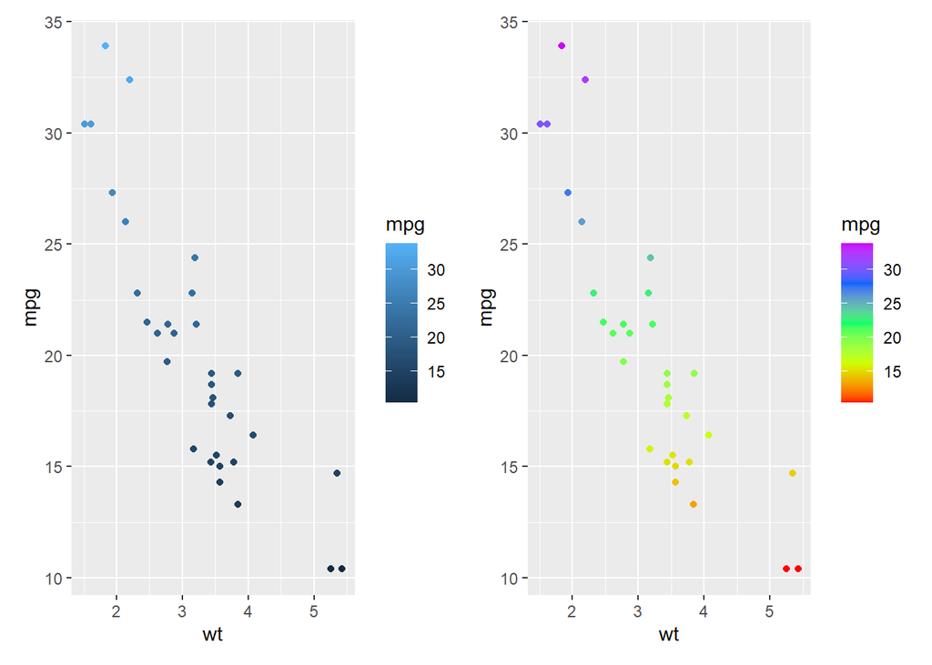

```r
# Scatter plot
# Color points by the mpg variable
p1 <- ggplot(mtcars, aes(x=wt, y=mpg, color=mpg)) + geom_point()

# Gradient between n colors
p2 <- p1 + scale_color_gradientn(colours = rainbow(5))

p1 + p2
```

# 3 arrangeing plots

package `patchwork` provides very easy new way of arranging plots together.

you can arrange plots side by side with no overlap, or arrange plots on top of each other.

## 3.1 side by side

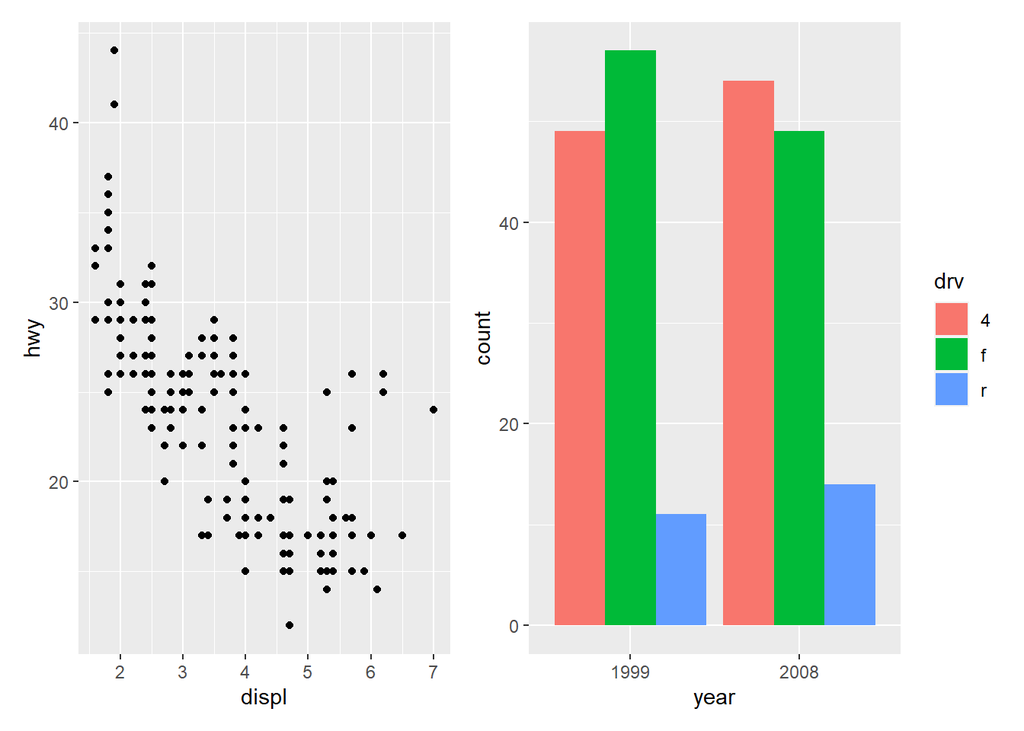

```r
library(patchwork)

p1 <- ggplot(mpg) +
  geom_point(aes(x = displ, y = hwy))

p2 <- ggplot(mpg) +
  geom_bar(aes(x = as.character(year), fill = drv), position = "dodge") +
  labs(x = "year")

p3 <- ggplot(mpg) +
  geom_density(aes(x = hwy, fill = drv), colour = NA) +
  facet_grid(rows = vars(drv))

p4 <- ggplot(mpg) +
  stat_summary(aes(x = drv, y = hwy, fill = drv), geom = "col", fun.data = mean_se) +
  stat_summary(aes(x = drv, y = hwy), geom = "errorbar", fun.data = mean_se, width = 0.5)

p1 + p2
```

`+` does not specify any specific layout.

3 plots together will create a 1x3 grid while adding 4 plots together will create a 2x2 grid.

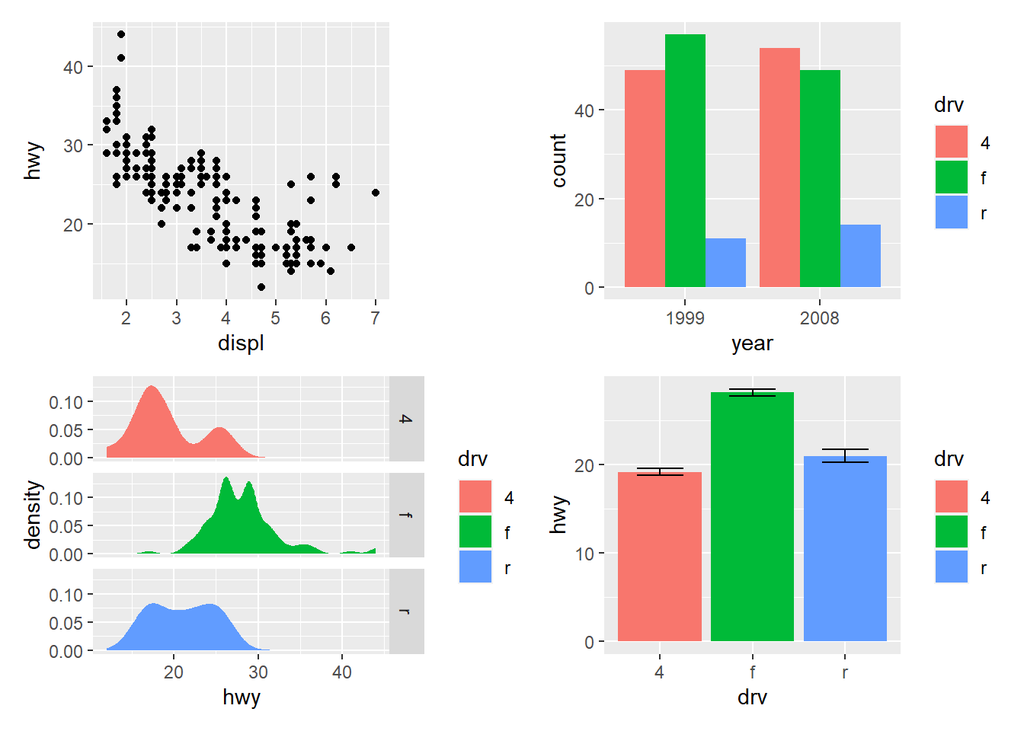

```r
p1 + p2 + p3 + p4
```

all plotting regions are aligned y-axis titles in the two left-most plots are aligned despite the axis text in the bottom left plot being wider.

control on the layout

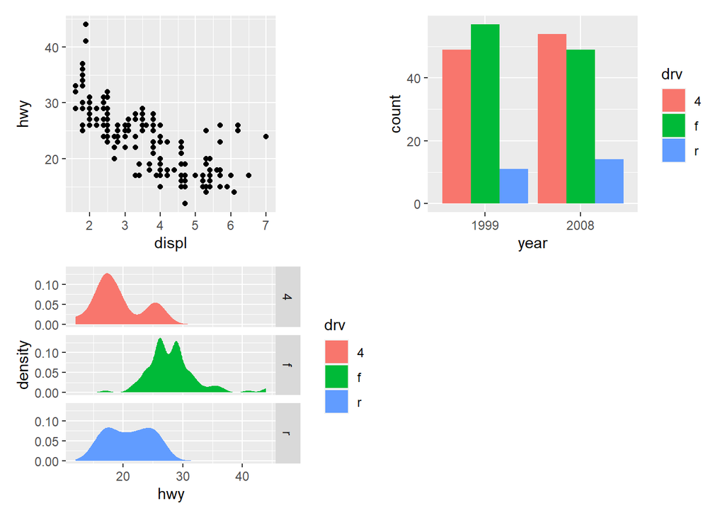

```r
p1 + p2 + p3 + plot_layout(ncol = 2)
```

to force horisontal lay use `|` , for vertical use `/`

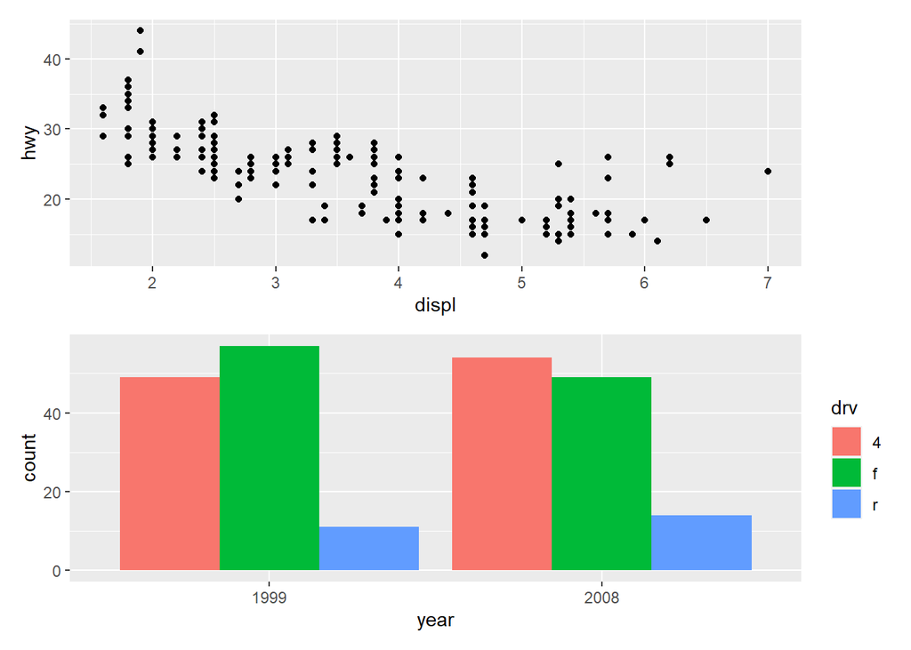

```r
p1 / p2
```

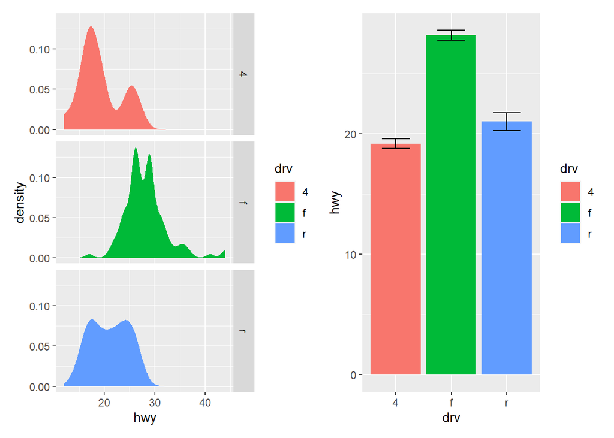

```r
p3 | p4
```

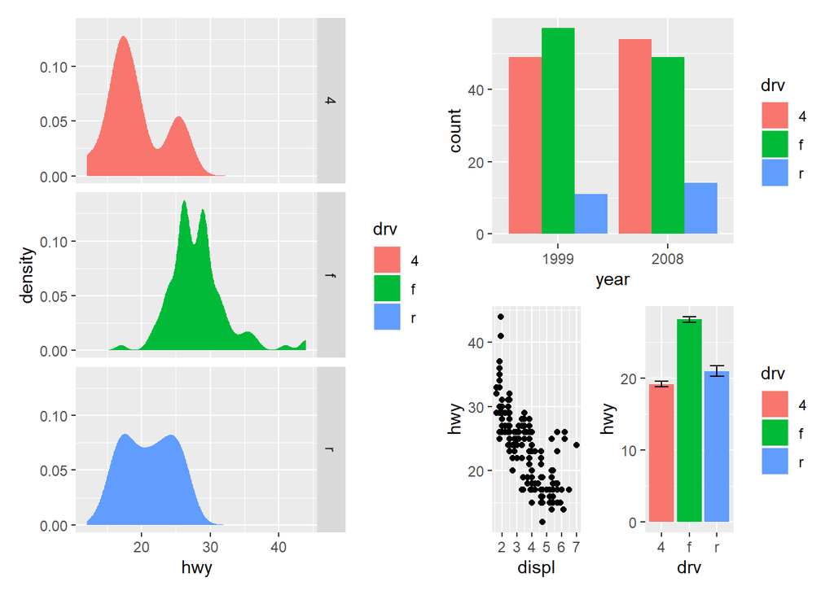

```r
p3 | (p2 / (p1 | p4))
```

collect guides together

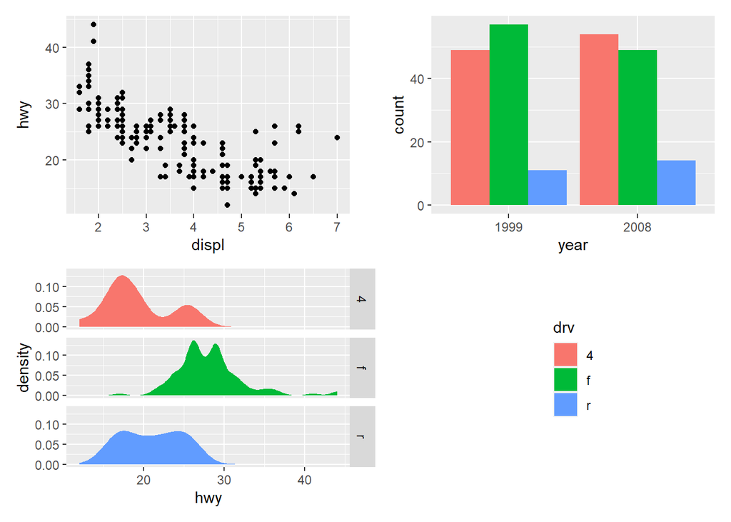

```r
p1 + p2 + p3 + guide_area() + plot_layout(ncol = 2, guides = "collect")
```

it will only remove guides that are exactly alike.

modify subplots

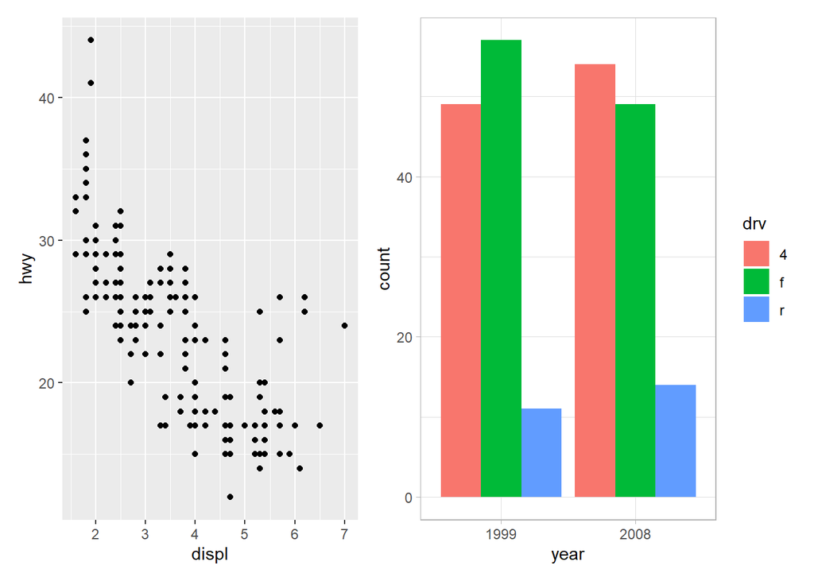

```r
p12 <- p1 + p2
p12[[2]] <- p12[[2]] + theme_light()
p12
```

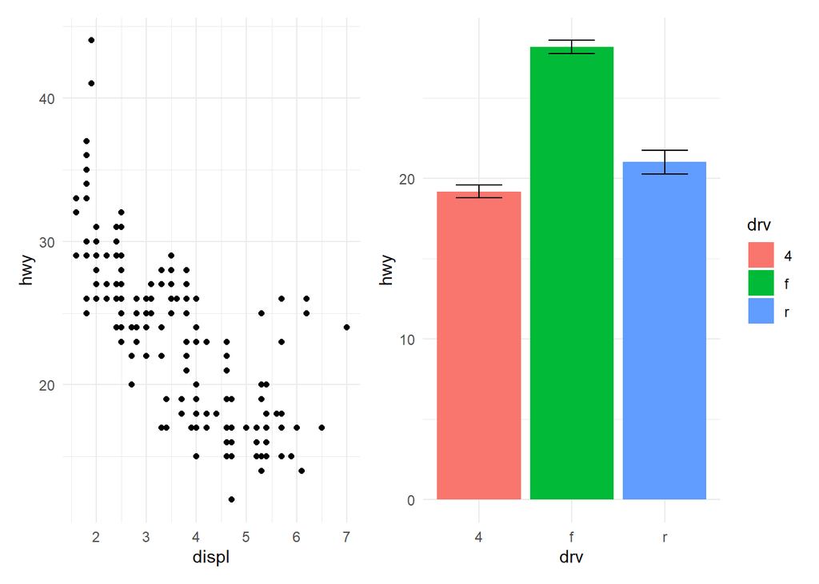

```r
p1 + p4 & theme_minimal()
```

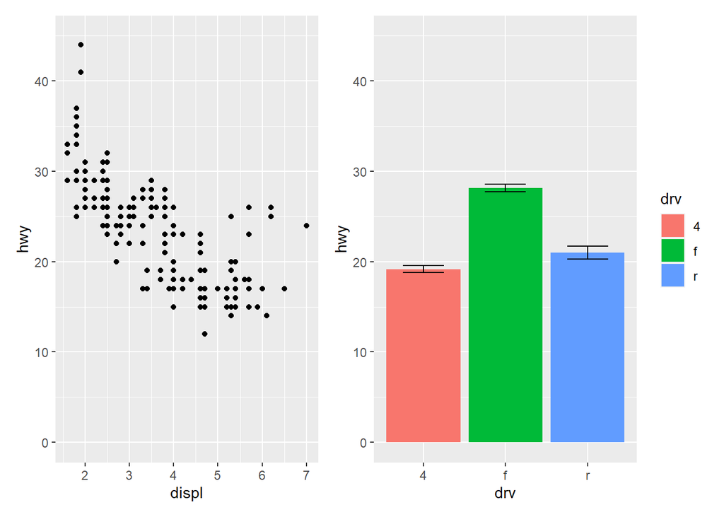

```r
p1 + p4 & scale_y_continuous(limits = c(0, 45))
```

adding annotation

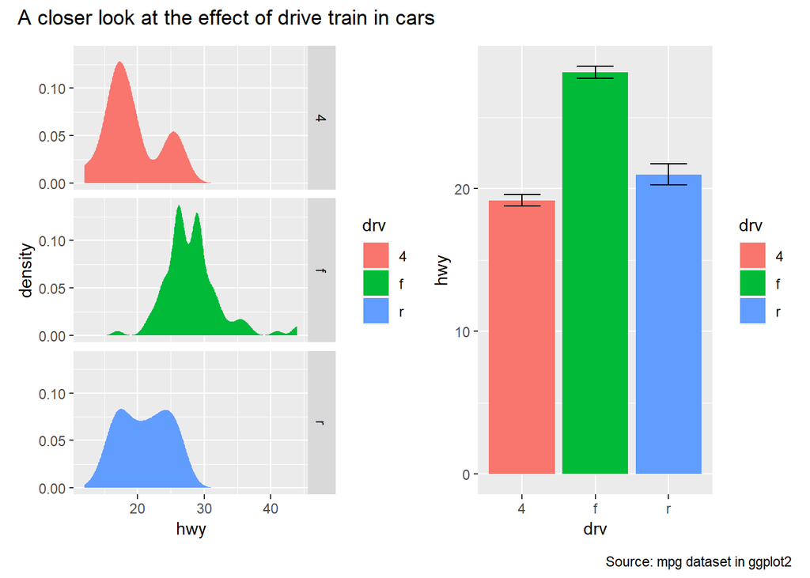

```r
p34 <- p3 + p4 + plot_annotation(
  title = "A closer look at the effect of drive train in cars",
  caption = "Source: mpg dataset in ggplot2"
)
p34
```

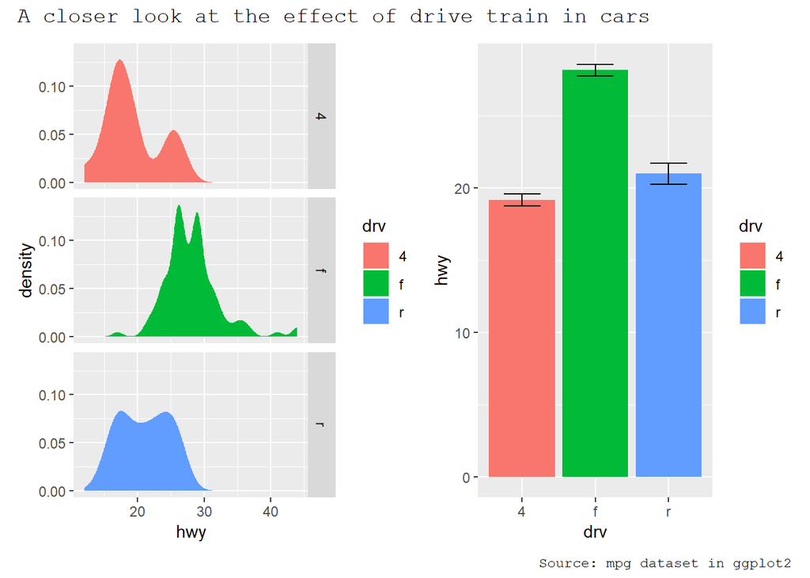

```r
p34 + plot_annotation(theme = theme_gray(base_family = "mono"))
```

tag plots

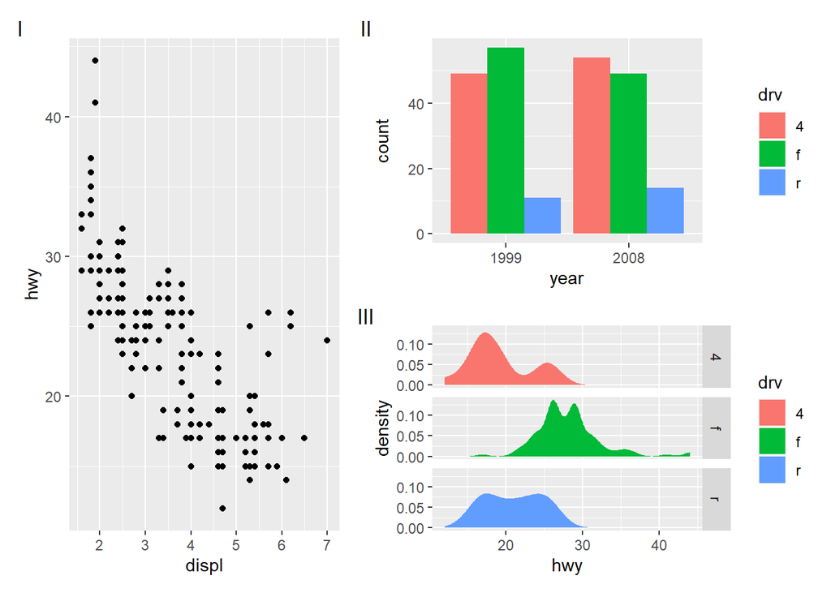

```r
p123 <- p1 | (p2 / p3)
p123 + plot_annotation(tag_levels = "I") # Uppercase roman numerics
```

## 3.2 on top of

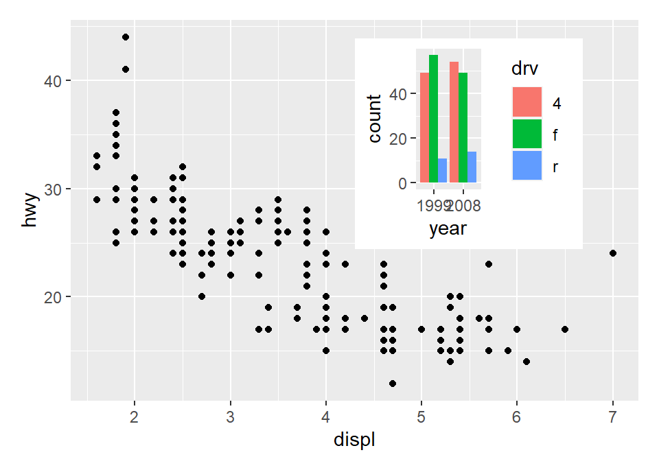

```r
p1 + inset_element(p2, left = 0.5, bottom = 0.4, right = 0.9, top = 0.95)
```

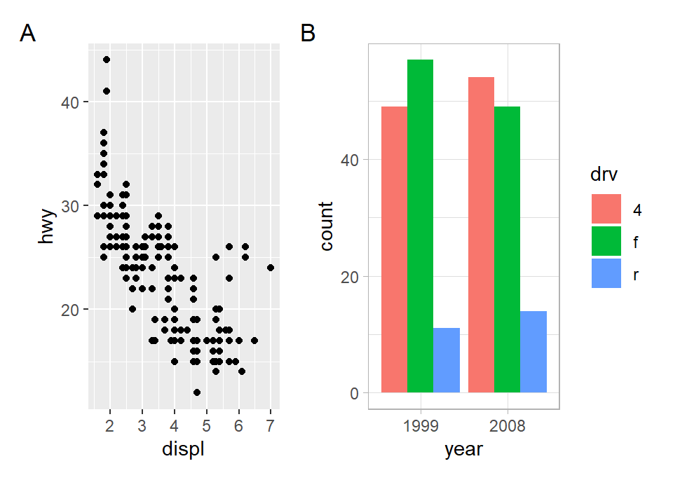

```r
p12 + plot_annotation(tag_levels = 'A')
```

## 3.3 wrapping up

There other options to arrange plots together: `gridExtra::grid.arrange()` and `cowplot::plot_grid` for instance `gridExtra` allow adding non ggplot objects, we can combine it with patchwork syntax

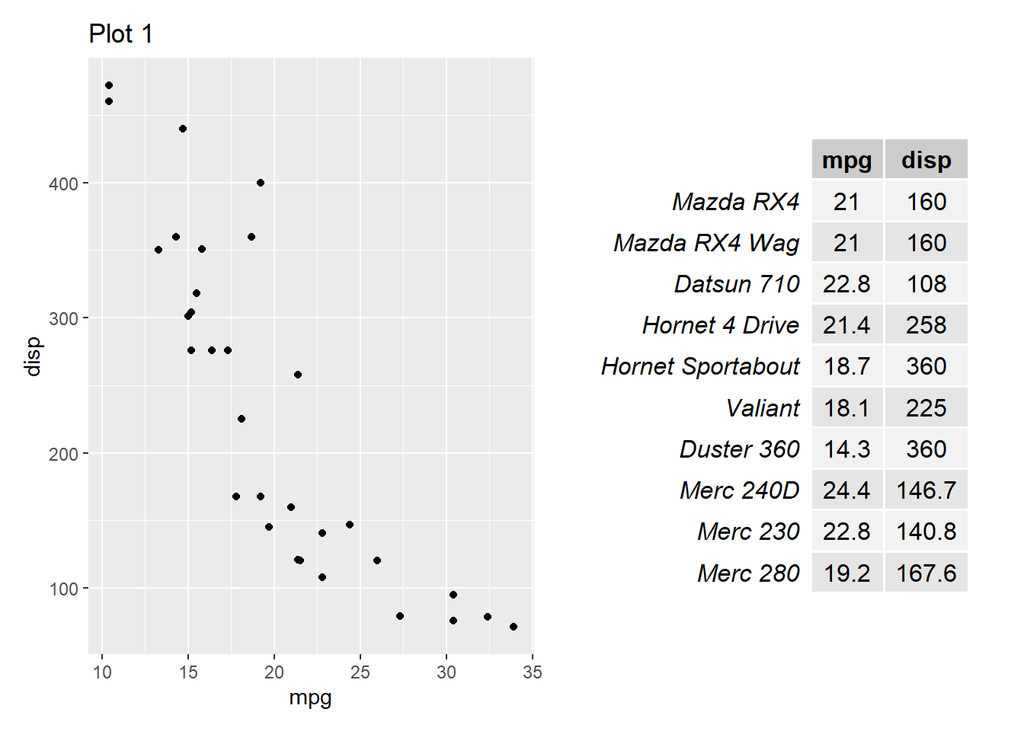

```r
p1 <- ggplot(mtcars) +
  geom_point(aes(mpg, disp)) +
  ggtitle('Plot 1')

p1 + gridExtra::tableGrob(mtcars[1:10, c('mpg', 'disp')])
```